# Relatório Atividade Semana 7

Fernando Bispo

26/09/2021

# 1 Primeira Questão

## 1.1 Introdução

O conjunto de dados (**dados1**) contém as observações acerca do tempo de permanência na chamada telefônica dos clientes da companhia aérea e o tipo de áudio utilizado no momento em que os clientes aguardam atendimento, sendo estas variáveis quantitativa e qualitativa respectivamente.

O intuito é comparar a distribuição do tempo de espera dos clientes com os diferentes tipos de áudio, sendo estes: um anúncio sobre a companhia aérea e suas promoções atuais, música de elevador ou música clássica gravada.

Para tanto será utilizado o teste de hipótese de Análise de Variância de um fator, abreviadamente denominado **ANOVA** pois se faz necessário a comparação entre as variáveis, sendo estas compostas por mais de 2 classes.

## 1.2 Análise Descritiva

Antes de se iniciar a análise inferencial é necessário fazer uma análise descritiva a fim de se gerar uma interpretação preliminar. Analisando o BoxPlot (Figura 1a) é possível identificar um comportamento assimétrico entre as categorias de tipos de áudio. Os clientes que escutaram Música Clássica aguardaram por mais tempo até o atendimento, quando comparado aos clientes que aguardaram ouvindo os outros tipos de áudio. É possível identificar que há uma maior intercessão entre os BoxPlots dos indivíduos que escutaram o Anúncio e os que escutaram Música de Elevador, indicando que não há diferenciação entre esses indivíduos quanto ao tempo esperado.

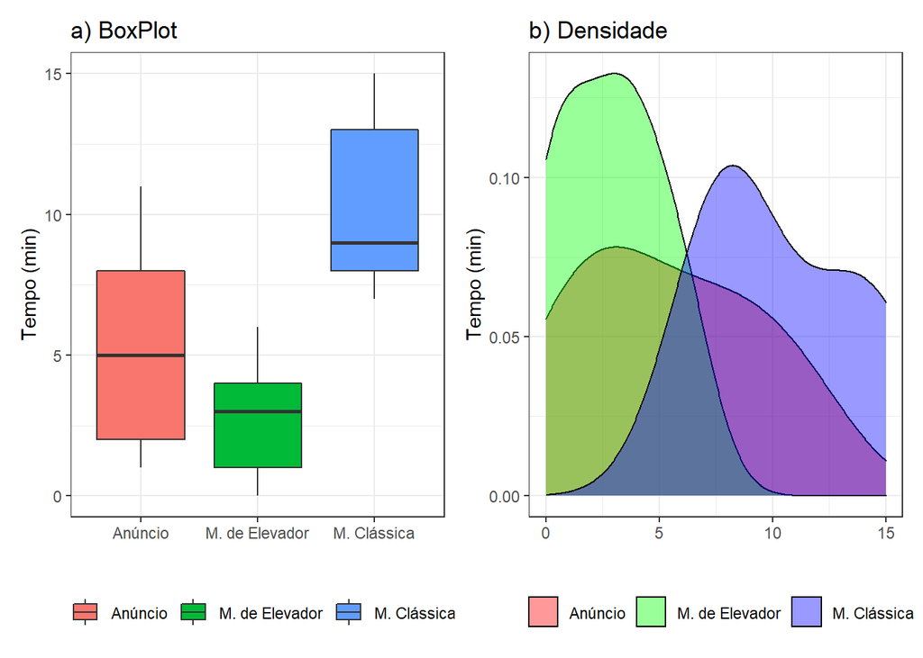

Na Tabela 1 há medidas resumo dos dados, em que é possívem identificar maior dispersão (variabilidade) no grupo que ouviu o Anúncio e que em média o grupo que ouviu Música Clássica permaneceu por um maior tempo de espera.

Tabela 1: Medidas Resumo

| Tipo de Áudio | Min | Q1 | Media | MD | Q3 | Max | SD |
| --- | --- | --- | --- | --- | --- | --- | --- |
| Anúncio | 1 | 2 | 5.4 | 5 | 8 | 11 | 4.16 |
| Música de Elevador | 0 | 1 | 2.8 | 3 | 4 | 6 | 2.39 |
| Música Clássica | 7 | 8 | 10.4 | 9 | 13 | 15 | 3.44 |

## 1.3 Análise Inferencial

Antes da aplicação do teste ANOVA é necessário constatar algumas premissas:

1. Independência dos dados amostrais;
2. Normalidade de distribuição entre os dados;
3. Igualdade da Variância Populacional (Homogeneidade).

### 1.3.1 Análise dos pré requisitos

#### 1.3.1.1 Verificação da Independência

Para este ítem é assumido independência entre os dados do mesmo grupo e entre os dados dos grupos diferentes.

#### 1.3.1.2 Verificação da normalidade dos dados.

O método utilizado para verificação da normalidade entre os dados dos grupos é o método de *Shapiro-Wilk*, em que assume as seguintes hipóteses:

- **H<sub>0</sub>**: Os dados são provenientes de uma Distribuição Normal
- **H<sub>1</sub>**: Os dados **não são** provenientes de uma Distribuição Normal

```
##
##  Shapiro-Wilk normality tests
##
## data:  Tempo by Gravação
##
##                         W p-value
## Anúncio            0.9468  0.7147
## Música de Elevador 0.9738  0.8989
## Música Clássica    0.9017  0.4195
```

Utilizando como base o *p-value* a um nível de significância de 5%, há indícios suficientes para aceitar a normalidade entre os dados, não sendo rejeitada assim a hipótese H<sub>0</sub>.

#### 1.3.1.3 Verificação da homogeneidade das Variâncias

Para a realização da verificação da homogeneidade das Variâncias é realizado o teste de Levene, que consiste num teste com as seguintes hipóteses:

- **H<sub>0</sub>**: As variâncias dos grupos são homogêneas.
- **H<sub>1</sub>**: As variâncias dos grupos **não são** homogêneas.

```
## Levene's Test for Homogeneity of Variance (center = mean)
##       Df F value Pr(>F)
## group  2  1.2275 0.3273
##       12
```

Utilizando como base o *p-value* há um nível de significância de 5%, há indícios suficientes para aceitar a homogeneidade entre os grupos, não sendo rejeitada assim a hipótese H<sub>0</sub>.

Após as análise das premissas há constatação da viabilidade da utilização do teste ANOVA nos dados coletados.

### 1.3.2 Teste ANOVA

O teste de hipótese de Análise Variância assume as seguintes hipóteses:

- **H<sub>0</sub>**: As médias dos grupos são todas iguais para um nível de significância de 5%.
- **H<sub>1</sub>**: Pelo menos uma média dos grupos **não é** igual para um nível de significância de 5%.

```
##             Df Sum Sq Mean Sq F value Pr(>F)
## gravacao     2  149.2    74.6   6.431 0.0126 *
## Residuals   12  139.2    11.6
## ---
## Signif. codes:  0 '***' 0.001 '**' 0.01 '*' 0.05 '.' 0.1 ' ' 1
```

Conforme o nível de significãncia estabelecido, há indícios suficientes para rejeitar H<sub>0</sub> pois o *p-value* menor que 5%, ou seja, há diferença entre as médias dos grupos e para identificar entre quais grupos há essa diferença é realizada a análise de PostHoc pelo método de Bonferroni, sendo este o de maior precisão.

### 1.3.3 Análise de PostHoc

```
##
##   Posthoc multiple comparisons of means : Bonferroni
##     95% family-wise confidence level
##
## $gravacao
##                                    diff     lwr.ci    upr.ci   pval
## Música de Elevador-Anúncio         -2.6 -8.5871683  3.387168 0.7520
## Música Clássica-Anúncio             5.0 -0.9871683 10.987168 0.1161
## Música Clássica-Música de Elevador  7.6  1.6128317 13.587168 0.0125 *
##
## ---
## Signif. codes:  0 '***' 0.001 '**' 0.01 '*' 0.05 '.' 0.1 ' ' 1
```

Conclui-se que não existe diferênça entre os grupos que ouviram Música de Elevador e os que ouviram o Anúncio, nem entre os grupos que ouviram Música de Clássica e os que ouviram o Anúncio, mas existe diferença entre os grupos que ouviram Música de Clássica e os que ouviram Música de Elevador.

# 2 Segunda Questão

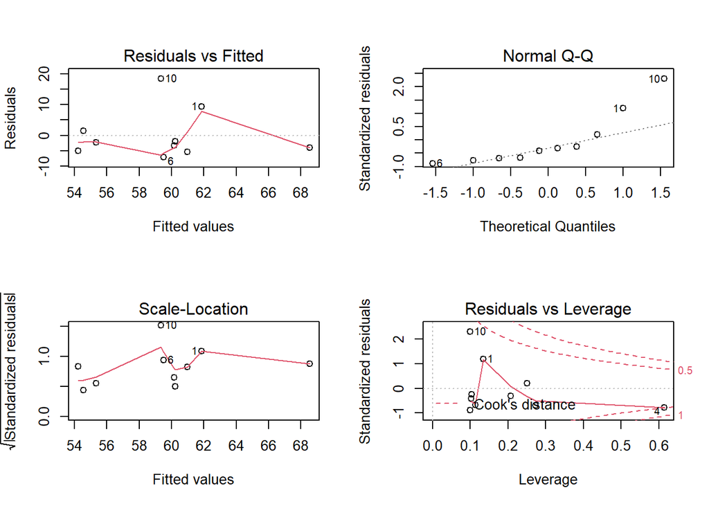

```
##
## Call:
## lm(formula = Wt ~ Ht, data = dados2)
##
## Residuals:
##     Min      1Q  Median      3Q     Max
## -7.1166 -4.7744 -2.8412  0.5696 18.4581
##
## Coefficients:
##             Estimate Std. Error t value Pr(>|t|)
## (Intercept) -36.8759    64.4728  -0.572    0.583
## Ht            0.5821     0.3892   1.496    0.173
##
## Residual standard error: 8.456 on 8 degrees of freedom
## Multiple R-squared:  0.2185, Adjusted R-squared:  0.1208
## F-statistic: 2.237 on 1 and 8 DF,  p-value: 0.1731
```